# Empleando R como Sistema de Información Geográfica (SIG)

Gustavo Ahumada

Sept 30, 2019

Este workshop busca proveer un conocimiento básico con varios aspectos de los sistemas de información geográfica (SIG), de tal manera que se entiendan el rango de los potenciales usos de los SIG en el trabajo aplicado y establecer bases adecuadas para incentivar estos.

# 1. Representación simple de datos espaciales

Los objetos espaciales usualmente son representados por datos tipo vector. Tales tipos de datos consisten en la geometría o la forma de los objetos. Por ejemplo, un conjunto de datos vector que contienen el limite de los paises del mundo (geometría) y también contienen su respectivo tamaño poblacional para el año 2010. Por otra parte, se tienen los datos espaciales continuos, los cuales son frecuentemente representados con datos tipo raster. A continuación se representante este tipo de datos utilizando R. Parte del codigo que será utilizado en esta sección está disponible en https://rspatial.org/spatial/index.html.

## 1.1 Datos tipo vector

```r
# Cargar librerias
library(pacman)
pacman::p_load(raster, sf, maptools, rgdal, ggplot2, tidyverse, broom)
```

```r
# Creación de 10 estaciones climaticas (llamadas de A a J)
nombre <- LETTERS[1:10]
longitud <- c(-116.7, -120.4, -116.7, -113.5, -115.5,
              -120.8, -119.5, -113.7, -113.7, -110.7)
latitud <- c(45.3, 42.6, 38.9, 42.1, 35.7, 38.9,
             36.2, 39, 41.6, 36.9)
est_climatic<- cbind(longitud, latitud)
# Simulación de datos de precipitación
set.seed(0)
precip <-round((runif(length(latitud))*10)^3)
```

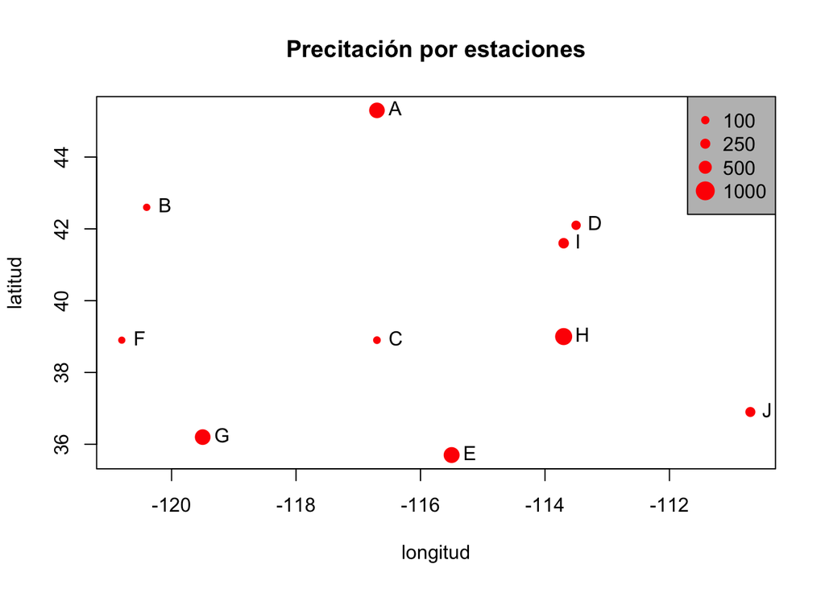

```r
nivel_precip <- 1 + precip/500
{plot(est_climatic, cex=nivel_precip, pch=20, col='red', main='Precitación por estaciones')
# Adicionar etiquetas
text.default(est_climatic, nombre, pos = 4)
# Adicionar leyenda
breaks <- c(100, 250, 500, 1000)
legend.psize <- 1+breaks/500
legend("topright", legend=breaks, pch=20, pt.cex=legend.psize, col='red', bg='gray')}
```

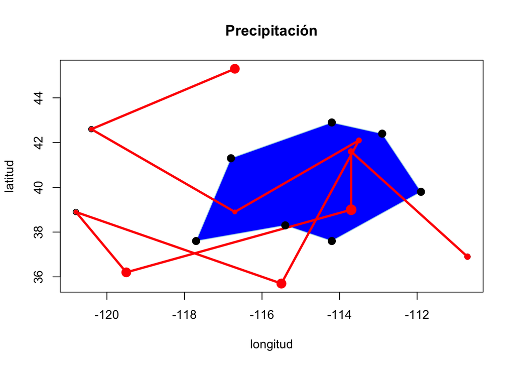

```r
# Adicionar lineas y polígonos al plot
longitud2 <- c(-116.8, -114.2, -112.9, -111.9, -114.2, -115.4, -117.7)
latitud2 <- c(41.3, 42.9, 42.4, 39.8, 37.6, 38.3, 37.6)
x <- cbind(longitud2, latitud2)
{plot(est_climatic, main='Precipitación')
polygon(x, col='blue', border='light blue')
lines(est_climatic, lwd=3, col='red')
points(x, cex=2, pch=20)
points(est_climatic, cex=nivel_precip, pch=20, col='red', main='Precipitación')}
```

```r
# Tabla de datos
tabla <- data.frame(longitud, latitud, nombre, precip)
tabla
```

```
##    longitud latitud nombre precip
## 1    -116.7    45.3      A    721
## 2    -120.4    42.6      B     19
## 3    -116.7    38.9      C     52
## 4    -113.5    42.1      D    188
## 5    -115.5    35.7      E    749
## 6    -120.8    38.9      F      8
## 7    -119.5    36.2      G    725
## 8    -113.7    39.0      H    843
## 9    -113.7    41.6      I    289
## 10   -110.7    36.9      J    249
```

## 1.2 Datos tipo raster

```r
# Crear un RasterLayer desde cero
rast <- raster(ncol=10, nrow=10, xmx=-80, xmn=-150, ymn=20, ymx=60)
rast
```

```
## class      : RasterLayer
## dimensions : 10, 10, 100  (nrow, ncol, ncell)
## resolution : 7, 4  (x, y)
## extent     : -150, -80, 20, 60  (xmin, xmax, ymin, ymax)
## crs        : +proj=longlat +datum=WGS84 +ellps=WGS84 +towgs84=0,0,0
```

```r
# Asignar valores a objetos tipo raster
values(rast) <- runif(ncell(rast))
rast
```

```
## class      : RasterLayer
## dimensions : 10, 10, 100  (nrow, ncol, ncell)
## resolution : 7, 4  (x, y)
## extent     : -150, -80, 20, 60  (xmin, xmax, ymin, ymax)
## crs        : +proj=longlat +datum=WGS84 +ellps=WGS84 +towgs84=0,0,0
## source     : memory
## names      : layer
## values     : 0.01339033, 0.9926841  (min, max)
```

```r
# Asignar el número de celdas(en este caso sobrescribir los valores previos)
values(rast) <- 1:ncell(rast)
rast
```

```
## class      : RasterLayer
## dimensions : 10, 10, 100  (nrow, ncol, ncell)
## resolution : 7, 4  (x, y)
## extent     : -150, -80, 20, 60  (xmin, xmax, ymin, ymax)
## crs        : +proj=longlat +datum=WGS84 +ellps=WGS84 +towgs84=0,0,0
## source     : memory
## names      : layer
## values     : 1, 100  (min, max)
```

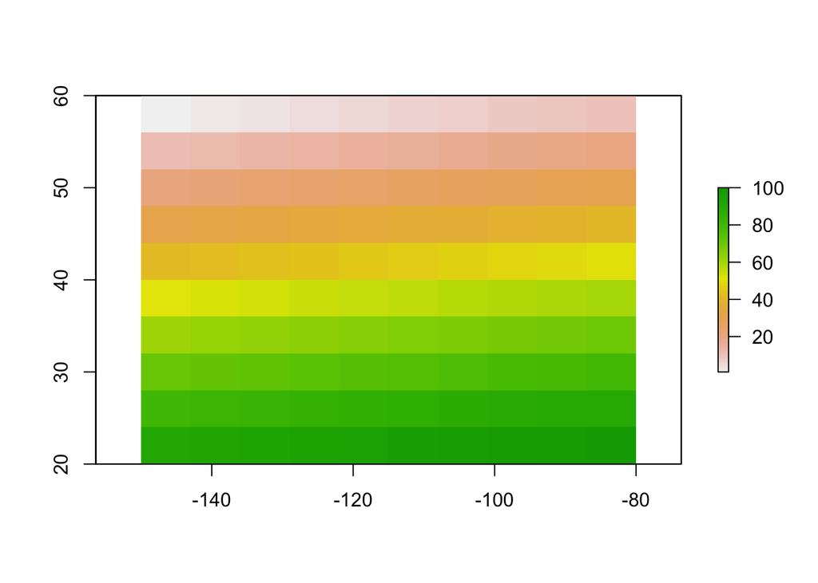

```r
plot(rast)
```

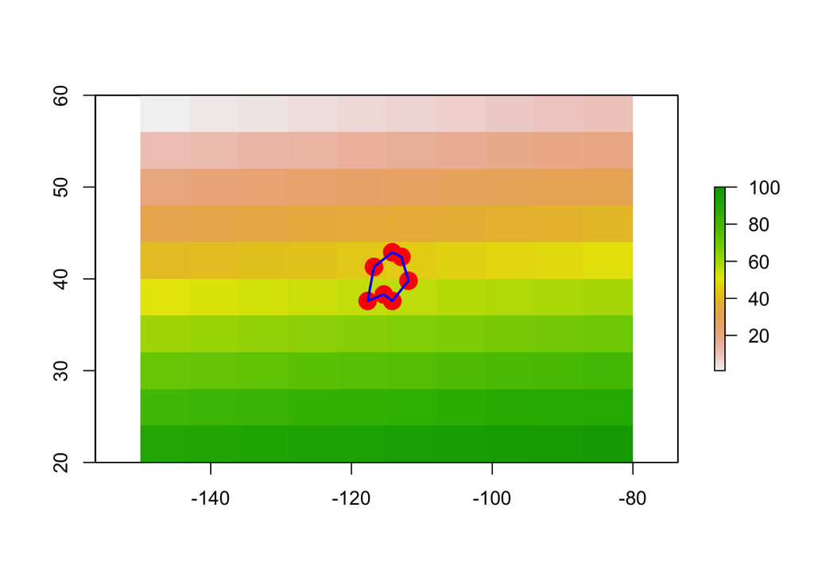

```r
# Adicionar puntos y poígonos
{rast <- raster(ncol=10, nrow=10, xmx=-80, xmn=-150, ymn=20, ymx=60)
# Asignar valores a objetos tipo raster
values(rast) <- runif(ncell(rast))
rast
# Asignar el número de celdas
values(rast) <- 1:ncell(rast)
rast
# Plottear objeto tipo raster
plot(rast)
# Adicionar puntos y poligonos
longitud <- c(-116.8, -114.2, -112.9, -111.9, -114.2, -115.4, -117.7)
latitud <- c(41.3, 42.9, 42.4, 39.8, 37.6, 38.3, 37.6)
lonlat <- cbind(longitud, latitud)
pols <- spPolygons(lonlat, crs='+proj=longlat +datum=WGS84')
points(lonlat, col='red', pch=20, cex=3)
plot(pols, border='blue', lwd=2, add=TRUE)}
```

# 2. Manipulación de datos tipo vector en R

```r
# Definir directorio de trabajo
# en Windows sería algo a esto setwd("C:/Users/gusahu/Google Drive/Workshop_socher/Section_II")
knitr::opts_knit$set(root.dir = '/Users/gusahu/Google Drive/Workshop_GIS_with_R/Section_II')
```

```r
# Cargar librerias
library(pacman)
pacman::p_load(raster, rgdal, rgeos, tidyverse, stringr, sf)
```

```r
# Limpiar ambiente de trabajo
g <- gc(reset = TRUE)
rm(list = ls())
options(scipen = 999)
```

```r
# Importar archivos shape (archivos tipo vector)
mps <- shapefile('./data/mpios_geo_ok2.shp')
```

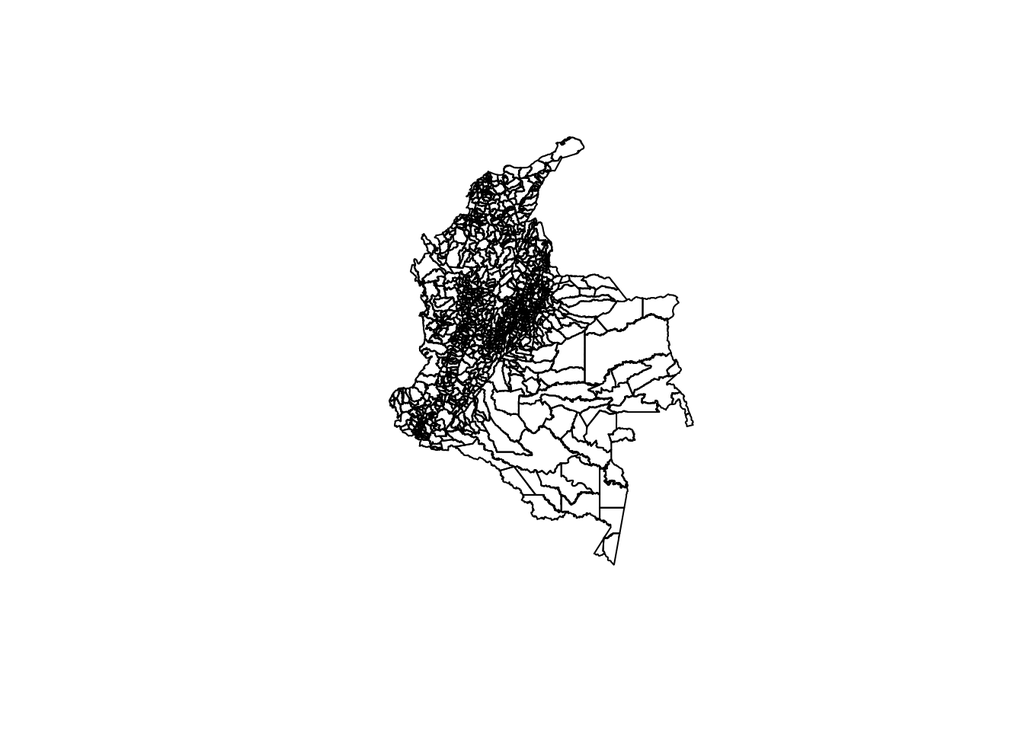

```r
# Plottear la geometría o el archivo .shp
plot(mps)
```

```r
# Realizar la unión (join) de una tabla con un shapefile
# importar archvios shape (archivos tipo vector)
shp <- st_read('./data/mpios_geo_ok.shp')
shp
```

```
## Simple feature collection with 1123 features and 13 fields
## geometry type:  POLYGON
## dimension:      XY
## bbox:           xmin: -81.73882 ymin: -4.228614 xmax: -66.84722 ymax: 13.38857
## epsg (SRID):    4326
## proj4string:    +proj=longlat +datum=WGS84 +no_defs
## First 10 features:
##    OBJECTID ID_ESPACIA AREA_OFICI        NOM_MUNICI COD_DEPTO FID_1
## 1         1      23189        644    CIÉNAGA DE ORO        23     7
## 2         2      23570        819      PUEBLO NUEVO        23     7
## 3         3      23068       1929            AYAPEL        23     7
## 4         4      23580       2062 PUERTO LIBERTADOR        23     7
## 5         5      23686        470        SAN PELAYO        23     7
## 6         6      70221         56           COVEÑAS        70    19
## 7         7      70523        174           PALMITO        70    19
```

[output cut: 25 more lines]

```r
# Importar archivos en formato .csv (.xls)
tbl <- read_csv('./data/produccion_cacao.csv')
tbl
```

```
## # A tibble: 5,478 x 10
##    COD_DPTO DPTO  MPIO  COD_MUNI CULTIVO PERIODO AREA_SEMBRADA_HA
##       <dbl> <chr> <chr>    <dbl> <chr>     <dbl>            <dbl>
##  1        5 ANTI… APAR…     5045 CACAO      2007             1830
##  2        5 ANTI… TURBO     5837 CACAO      2007             1002
##  3        5 ANTI… MACEO     5425 CACAO      2007              950
##  4        5 ANTI… YALI      5885 CACAO      2007              580
##  5        5 ANTI… NECO…     5490 CACAO      2007              523
##  6        5 ANTI… VEGA…     5858 CACAO      2007              520
##  7        5 ANTI… REME…     5604 CACAO      2007              405
##  8        5 ANTI… DABE…     5234 CACAO      2007              315
##  9        5 ANTI… "NAR…     5483 CACAO      2007              311
## 10        5 ANTI… SAN …     5659 CACAO      2007              307
## # … with 5,468 more rows, and 3 more variables: AREA_COSECHADA_HA <dbl>,
## #   PRODUCCION <dbl>, RDTOS <dbl>
```

```r
# Años disponible en archivo .csv
yrs <- unique(tbl$PERIODO)
yrs
```

```
##  [1] 2007 2008 2009 2010 2011 2012 2013 2014 2015 2016 2017
```

```r
tbl <- tbl %>% # pipe (%>%) es un operador que permite encadenar funciones
  filter(PERIODO == 2017) %>%
  mutate(MPIO = iconv(MPIO, to = 'latin1')) # transformación de variables en un data frame
```

```r
# Ver atributos de objetos
str(tbl)
```

```
## Classes 'spec_tbl_df', 'tbl_df', 'tbl' and 'data.frame': 526 obs. of  10 variables:
##  $ COD_DPTO         : num  91 91 5 5 5 5 5 5 5 5 ...
##  $ DPTO             : chr  "AMAZONAS" "AMAZONAS" "ANTIOQUIA" "ANTIOQUIA" ...
##  $ MPIO             : chr  NA "LETICIA" "TURBO" "CACERES" ...
##  $ COD_MUNI         : num  91540 91001 5837 5120 5490 ...
##  $ CULTIVO          : chr  "CACAO" "CACAO" "CACAO" "CACAO" ...
##  $ PERIODO          : num  2017 2017 2017 2017 2017 ...
##  $ AREA_SEMBRADA_HA : num  29 8 2476 1874 1856 ...
##  $ AREA_COSECHADA_HA: num  29 6 1761 870 1265 ...
##  $ PRODUCCION       : num  15 2 881 696 632 702 828 506 270 184 ...
##  $ RDTOS            : num  0.5 0.4 0.5 0.8 0.5 0.5 0.6 0.6 0.6 0.5 ...
```

```r
str(shp)
```

```
## Classes 'sf' and 'data.frame':   1123 obs. of  14 variables:
##  $ OBJECTID  : Factor w/ 1123 levels "1","10","100",..: 1 241 352 463 574 685 795 905 1016 2 ...
##  $ ID_ESPACIA: Factor w/ 1123 levels "11001","13001",..: 288 297 282 299 307 915 925 934 930 923 ...
##  $ AREA_OFICI: num  644 819 1929 2062 470 ...
##  $ NOM_MUNICI: Factor w/ 1043 levels "ABEJORRAL","ÁBREGO",..: 205 664 71 684 815 238 613 949 809 553 ...
##  $ COD_DEPTO : Factor w/ 34 levels "05","08","11",..: 10 10 10 10 10 22 22 22 22 22 ...
##  $ FID_1     : Factor w/ 34 levels "0","1","10","11",..: 32 32 32 32 32 12 12 12 12 12 ...
##  $ ID_ESPAC_1: Factor w/ 34 levels "05","08","11",..: 10 10 10 10 10 22 22 22 22 22 ...
##  $ AREA_OFI_1: num  26506 26506 26506 26506 26506 ...
##  $ NOMBRE_DPT: Factor w/ 34 levels "AMAZONAS","ANTIOQUIA",..: 15 15 15 15 15 30 30 30 30 30 ...
##  $ area_ha   : num  63749 79500 193262 165073 47257 ...
##  $ nombre    : Factor w/ 0 levels: NA NA NA NA NA NA NA NA NA NA ...
##  $ Shape_Leng: num  1.68 1.51 2.07 2.54 1.53 ...
##  $ Shape_Area: num  0.0524 0.0652 0.1586 0.1352 0.0388 ...
##  $ geometry  :sfc_POLYGON of length 1123; first list element: List of 1
##   ..$ : num [1:1769, 1:2] -75.7 -75.7 -75.7 -75.7 -75.7 ...
##   ..- attr(*, "class")= chr  "XY" "POLYGON" "sfg"
##  - attr(*, "sf_column")= chr "geometry"
##  - attr(*, "agr")= Factor w/ 3 levels "constant","aggregate",..: NA NA NA NA NA NA NA NA NA NA ...
##   ..- attr(*, "names")= chr  "OBJECTID" "ID_ESPACIA" "AREA_OFICI" "NOM_MUNICI" ...
```

```r
# Transformación ID espacial
shp <- shp %>%
  mutate(ID_ESPACIA = as.numeric(as.character(ID_ESPACIA)))
str(shp)
```

```
## Classes 'sf' and 'data.frame':   1123 obs. of  14 variables:
##  $ OBJECTID  : Factor w/ 1123 levels "1","10","100",..: 1 241 352 463 574 685 795 905 1016 2 ...
##  $ ID_ESPACIA: num  23189 23570 23068 23580 23686 ...
##  $ AREA_OFICI: num  644 819 1929 2062 470 ...
##  $ NOM_MUNICI: Factor w/ 1043 levels "ABEJORRAL","ÁBREGO",..: 205 664 71 684 815 238 613 949 809 553 ...
##  $ COD_DEPTO : Factor w/ 34 levels "05","08","11",..: 10 10 10 10 10 22 22 22 22 22 ...
##  $ FID_1     : Factor w/ 34 levels "0","1","10","11",..: 32 32 32 32 32 12 12 12 12 12 ...
##  $ ID_ESPAC_1: Factor w/ 34 levels "05","08","11",..: 10 10 10 10 10 22 22 22 22 22 ...
##  $ AREA_OFI_1: num  26506 26506 26506 26506 26506 ...
##  $ NOMBRE_DPT: Factor w/ 34 levels "AMAZONAS","ANTIOQUIA",..: 15 15 15 15 15 30 30 30 30 30 ...
##  $ area_ha   : num  63749 79500 193262 165073 47257 ...
##  $ nombre    : Factor w/ 0 levels: NA NA NA NA NA NA NA NA NA NA ...
##  $ Shape_Leng: num  1.68 1.51 2.07 2.54 1.53 ...
##  $ Shape_Area: num  0.0524 0.0652 0.1586 0.1352 0.0388 ...
##  $ geometry  :sfc_POLYGON of length 1123; first list element: List of 1
##   ..$ : num [1:1769, 1:2] -75.7 -75.7 -75.7 -75.7 -75.7 ...
##   ..- attr(*, "class")= chr  "XY" "POLYGON" "sfg"
##  - attr(*, "sf_column")= chr "geometry"
##  - attr(*, "agr")= Factor w/ 3 levels "constant","aggregate",..: NA NA NA NA NA NA NA NA NA NA ...
##   ..- attr(*, "names")= chr  "OBJECTID" "ID_ESPACIA" "AREA_OFICI" "NOM_MUNICI" ...
```

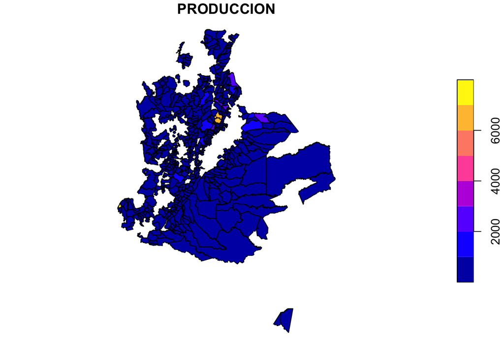

```r
# Realizar unión entre una table y un shapefile
fnl <- inner_join(x = shp, y = tbl, by = c('ID_ESPACIA' = 'COD_MUNI'))
fnl %>%
  dplyr::select(PRODUCCION) %>%
  plot()
```

```r
# Exportar el nuevo archivo espacial con las nuevas características
st_write(obj = fnl, dsn = './_shp', layer = 'producción_cacao', driver = 'ESRI shapefile', update = TRUE)
```

```
## Writing layer `producción_cacao' to data source `./_shp' using driver `ESRI shapefile'
## features:       526
## fields:         22
## geometry type:  Polygon
```

# 3. Manipulación de datos tipo ráster en R

### Descripción de los datos empleados

Los datos utilizados a lo largo de la sección 3 provienen de WorldClim-Global Data http://www.worldclim.org. Para esta sección empleamos datos climáticos para el año 2050 con una resolución de 10 minutos (tamaño de píxel de 20Km*20Km). El modelo climatico mediante el cual fueron construdios los datos es el modelo HadGEM2-CC bajo un escenario de alta probabilidad de ocurrencia. Para más información visitar https://portal.enes.org/models/earthsystem-models/metoffice-hadley-centre/hadgem2-es.

## 3.1 Manipulación de archivos tipo ráster

```r
# Definir directorio de trabajo
# en Windows sería algo a esto setwd("C:/Users/gusahu/Google Drive/Workshop_socher/Section_III")
knitr::opts_knit$set(root.dir = '/Users/gusahu/Google Drive/Workshop_GIS_with_R/Section_III')
```

```r
# Cargar librerias
library(pacman)
pacman::p_load(raster, rgdal, maptools)
```

```r
# Limpiar ambiente de trabajo
g <- gc(reset = TRUE)
rm(list = ls())
options(scipen = 999)
```

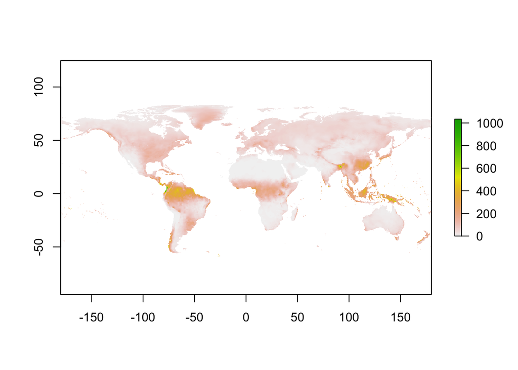

```r
# Importar archivo raster de precipitación del mes de mayo
pr_mayo<- raster('./hg85pr50/hg85pr505.tif')
plot(pr_mayo)
```

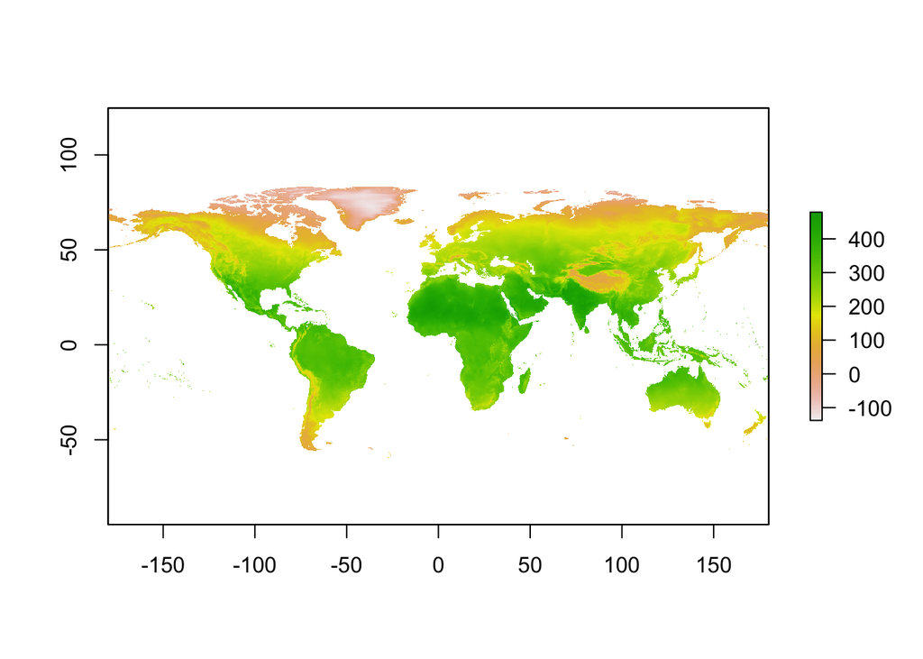

```r
# Importar archivo raster de temperatura máxima del mes de mayo
tx_mayo<- raster('./hg85tx50/hg85tx505.tif')
plot(tx_mayo)
```

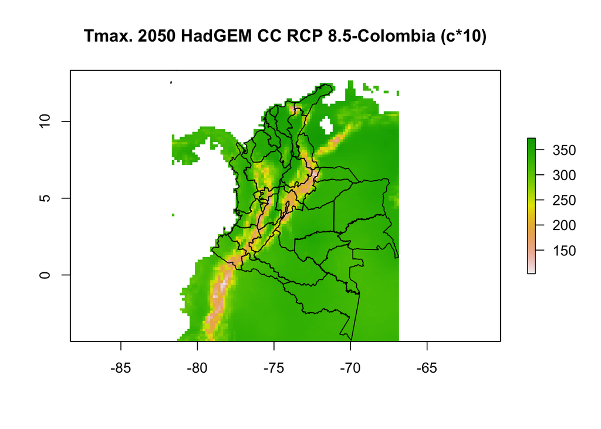

```r
# Cargar capa de polígono
{col<- readOGR('./shp_dpto/deptos_wgs84.shp')
# Cortar raster al área del polígono
tx_mayo_col<- crop(tx_mayo,col)
# Plotear raster
plot(tx_mayo_col, main = "Tmax. 2050 HadGEM CC RCP 8.5-Colombia (c*10)")
plot(col, add=TRUE)}
```

## 3.2 Operaciones entre rásteres - cálculo Indice de Aridez de Martonne (1926)

En esta sub-sección vamos a realizar algunar operaciones entre archivos ráster, y a través de estas operaciones realizaremós el cálculo del índice de ridez de Martanne ($I_m=P/(T_m+10)$). Para tal fin, llevaremos a cabo un conjunto de operaciones puntuales.

Primer paso: cargar capas ráster.

```r
# cargar raster por lotes
grids<-list.files("./hg85tn50", pattern = ".tif", full.names = TRUE)  # temperatura mínima
grids2<-list.files("./hg85tx50", pattern = ".tif", full.names = TRUE) # temperatura máxima
grids3<-list.files("./hg85pr50", pattern = ".tif", full.names = TRUE) # precipitación
```

```r
# crear raster stack
tn_stack<- stack(grids)
tx_stack<- stack(grids2)
pr_stack<- stack(grids3)
```

Segundo paso: operar rásteres

```r
tn_promedio <- ((sum(tn_stack))/120) # temperatura minima promedio anual
tx_promedio <- ((sum(tx_stack))/120) # temperatura maxima promedio anual
tm_promedio <- mean(tn_promedio, tx_promedio) # cáulo temperatura media anual
pr_total <- sum(pr_stack) # precipitación acumulada anual
```

Tercer paso: cargar una capa vectorial de polígono

```r
col<- readOGR('./shp_dpto/deptos_wgs84.shp')
```

Cuarto paso: cortar raster al área del polígono

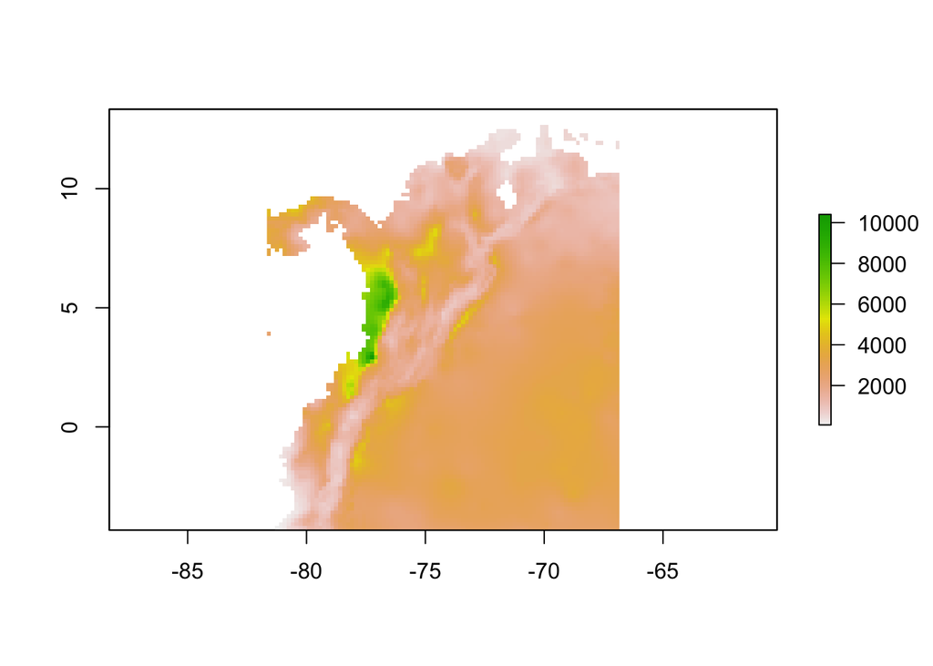

```r
pr_total_col<- crop(pr_total,col)
plot(pr_total_col)  # plot precipitación anual acumulada
```

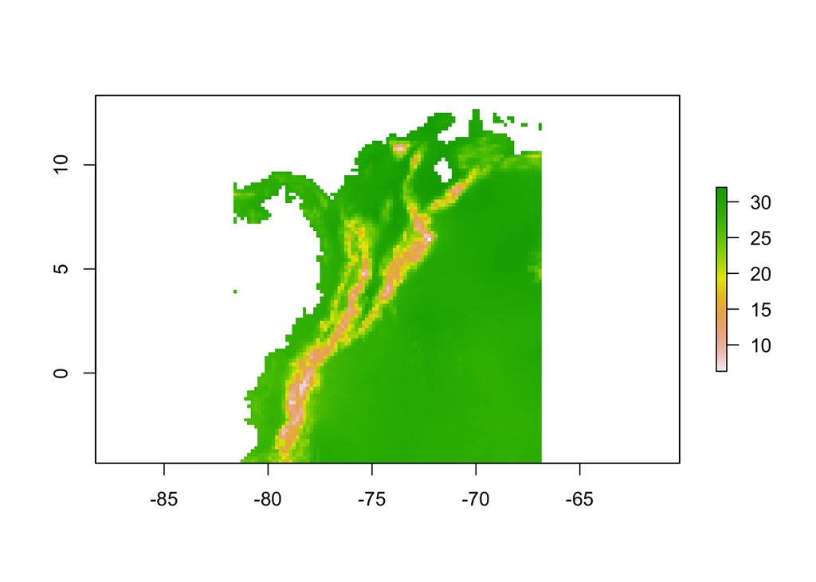

```r
tm_promedio_col<- crop(tm_promedio,col)
plot(tm_promedio_col) # plot temperatura media anual
```

Quinto paso: calcular Índice de Aridez de Martonne para el año 2050

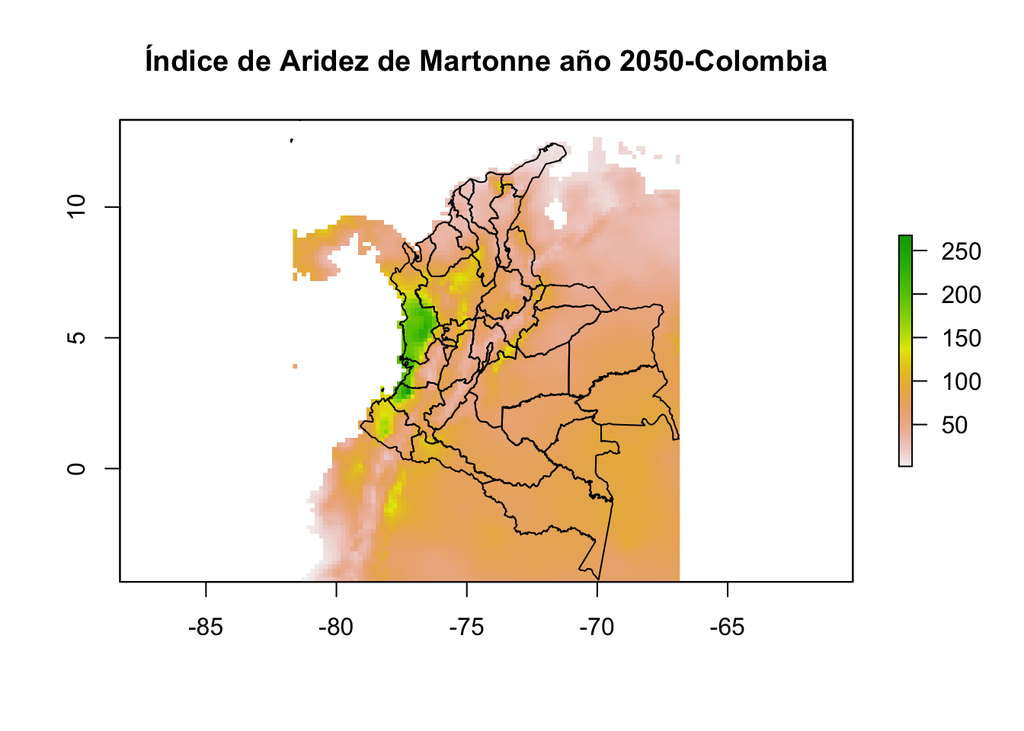

```r
ind_a <- pr_total_col / (tm_promedio_col + 10)
plot(ind_a, main = "Índice de Aridez de Martonne año 2050-Colombia")
plot(col, add=TRUE) # adicionar capa vectorial de polígono
```

Sexto paso: exportar a *.tif

```r
writeRaster(ind_a, filename = "Ia_2050", format="GTiff", overwrite=TRUE)
```

# 4. Haciendo mapas con R: desde mapas estáticos hasta mpas interactivos

## 4.1 Mapas estáticos en R

### 4.1.1 Haciendo mapas estáticos empleando datos tipo raster

```r
# Definir directorio de trabajo
# en Windows sería algo a esto setwd("C:/Users/gusahu/Google Drive/Workshop_socher/Section_IV")
knitr::opts_knit$set(root.dir = '/Users/gusahu/Google Drive/Workshop_GIS_with_R/Section_IV/Raster_data')
```

```r
# Cargar librerias
require(pacman)
pacman::p_load(raster, rgdal, rgeos, stringr, tidyverse, RColorBrewer, ggpubr)
```

```r
# Limpiar ambiente de trabajo
g <- gc(reset = TRUE)
rm(list = ls())
options(scipen = 999)
```

```r
# Cargar datos de precipitación y shapefile de municipios
# Precipitación acumulada anual
grids<-list.files("./hg85pr50_5", pattern = ".tif", full.names = TRUE)
pr_stack<- stack(grids)
pr_total <- sum(pr_stack)
mps <- shapefile('./mpiosColombia/mpios_geo_ok.shp')
```

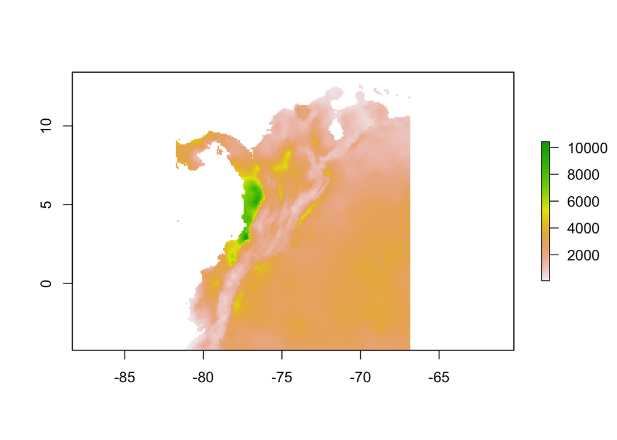

```r
# cortar raster al área del polígono
pr_col<- crop(pr_total,mps)
plot(pr_col)
```

```r
# Procesando los datos
dpt<- readOGR('./shp_dpto/deptos_wgs84.shp')
#dpt <- aggregate(mps, 'NOMBRE_DPT')
gjr <- dpt[dpt@data$NOMBRE_DPT %in% "LA GUAJIRA",]
ch <- dpt[dpt@data$NOMBRE_DPT %in% "CHOCO",]
```

```r
pr_gjr <- raster::crop(pr_col, gjr) %>%
  raster::mask(., gjr) %>%
  rasterToPoints() %>%
  as_tibble() %>%
  mutate(dpt = 'La Guajira')
pr_ch <- raster::crop(pr_col, ch) %>%
  raster::mask(., ch) %>%
  rasterToPoints() %>%
  as_tibble() %>%
  mutate(dpt = 'Chocó')
pr <- rbind(pr_gjr, pr_ch)
```

```r
pr %>% filter(dpt == 'La Guajira') %>% pull(layer) %>% max()
```

```
## [1] 2460
```

```r
pr %>% filter(dpt == 'Chocó') %>% pull(layer) %>% max()
```

```
## [1] 9528
```

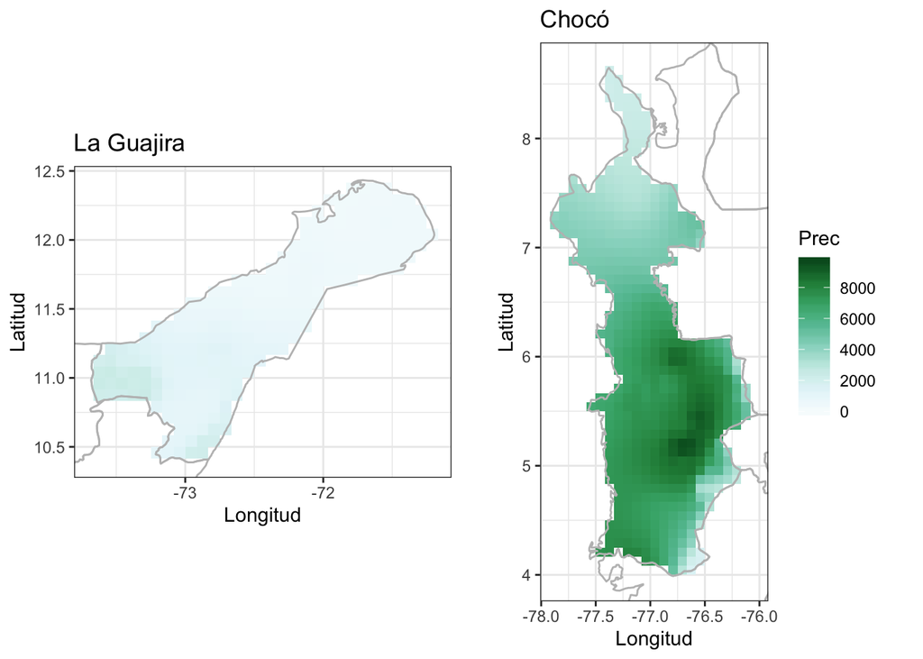

```r
map_grj <- ggplot(pr %>% filter(dpt == 'La Guajira'))  +
  geom_tile(aes(x = x, y =  y, fill = layer)) +
  scale_fill_gradientn(colours = RColorBrewer::brewer.pal(n = 8, name = "BuGn"),
                       na.value = 'white', limits = c(0, 9700), breaks = seq(0, 9700, 2000)) +
  geom_polygon(data = dpt, aes(x=long, y = lat, group = group), color = 'grey', fill='NA') +
  ggtitle('La Guajira') +
  theme_bw() +
  coord_equal(xlim = extent(gjr)[1:2], ylim = extent(gjr)[3:4]) +
  labs(x = 'Longitud', y = 'Latitud', fill = 'Pr') +
  theme(legend.position = 'none')
map_ch <- ggplot(pr %>% filter(dpt == 'Chocó'))  +
  geom_tile(aes(x = x, y =  y, fill = layer)) +
  ggtitle('Chocó') +
  geom_polygon(data = dpt, aes(x=long, y = lat, group = group), color = 'grey', fill='NA') +
  scale_fill_gradientn(colours = RColorBrewer::brewer.pal(n = 8, name = "BuGn"),
                       na.value = 'white', limits = c(0, 9700), breaks = seq(0, 9700, 2000)) +
  theme_bw() +
  coord_equal(xlim = extent(ch)[1:2], ylim = extent(ch)[3:4]) +
  labs(x = 'Longitud', y = 'Latitud', fill = 'Prec') +
  theme(legend.position = 'right')
maps2 <- gridExtra::grid.arrange(map_grj, map_ch, ncol = 2)
```

```r
ggsave(plot = maps2, filename = './mapa_prec2.png', width = 12, height = 9, units = 'in', dpi = 300)
```

### 4.1.2 Haciendo mapas estáticos empleando datos tipo vector

```r
# Definir directorio de trabajo
# en Windows sería algo a esto setwd("C:/Users/gusahu/Google Drive/Workshop_socher/Section_IV")
knitr::opts_knit$set(root.dir = '/Users/gusahu/Google Drive/Workshop_GIS_with_R/Section_IV/Vector_data')
```

```r
# Limpiar ambiente de trabajo
g <- gc(reset = TRUE)
rm(list = ls())
options(scipen = 999)
```

```r
# Cargar librerias
library(pacman)
pacman::p_load(raster, rgdal, rgeos, tidyverse, stringr, sf, broom)
```

```r
shp <- shapefile('./meanTemp/mean_temp.shp')
#shp@data$MEAN
#shp@data$NOM_MUNICI
#shp@data$NOMBRE_DPT
dpto <- unique(shp@data$NOMBRE_DPT)
```

```r
# convertir shapefile en una tabla
tdy <- broom::tidy(shp, 'ID_ESPACIA')
dfm <- tibble(id_espacial = shp@data$ID_ESPACIA, mpio = shp@data$NOM_MUNICI, temp = shp@data$MEAN)
dfm <- inner_join(tdy, dfm, by = c('id' = 'id_espacial'))
```

```r
# importaar archivos .rds
pnm <- readRDS(file = "gadm36_PAN_0_sp.rds")
ecu <- readRDS(file = "gadm36_ECU_0_sp.rds")
ven <- readRDS(file = "gadm36_VEN_0_sp.rds")
per <- readRDS(file = "gadm36_PER_0_sp.rds")
bra <- readRDS(file = "gadm36_BRA_0_sp.rds")
```

```r
pnm <- broom::tidy(pnm, 'NAME_0')
ecu <- broom::tidy(ecu, 'NAME_0')
ven <- broom::tidy(ven, 'NAME_0')
per <- broom::tidy(per, 'NAME_0')
bra <- broom::tidy(bra, 'NAME_0')
```

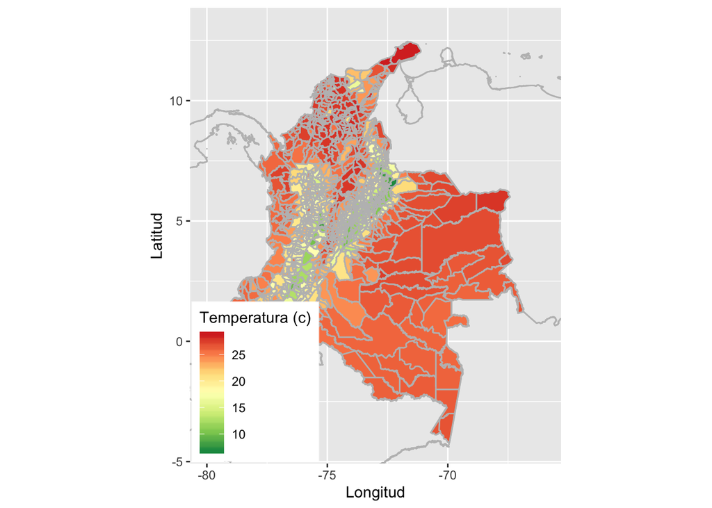

```r
# Mapa temperatura promedio en colombia año 2015
map <- ggplot()+
  geom_polygon(data = dfm, aes(x = long, y = lat, group = id, fill = temp), colour = 'grey') +
  scale_fill_distiller(palette = 'RdYlGn') +
  geom_polygon(data = pnm, aes(x = long, y = lat, group = group), fill = NA, colour = 'grey')+
  geom_polygon(data = ecu, aes(x = long, y = lat, group = group), fill = NA, colour = 'grey')+
  geom_polygon(data = ven, aes(x = long, y = lat, group = group), fill = NA, colour = 'grey')+
  geom_polygon(data = per, aes(x = long, y = lat, group = group), fill = NA, colour = 'grey')+
  geom_polygon(data = bra, aes(x = long, y = lat, group = group), fill = NA, colour = 'grey')+
  coord_equal(xlim = c(-80, -66), ylim = c(-4.22, 13)) +
  xlab('Longitud') +
  ylab('Latitud') +
  labs(fill = 'Temperatura (c)') +
  theme(legend.justification = c(0,0),
        legend.position = c(0.005, 0.005),
        legend.background = element_rect(fill = alpha('white', 1), colour = alpha('white', 0.4)))
ggsave(plot = map, filename = 'mapa_temp.png', units = 'in', width = 6, height = 7.5, dpi = 300)
map
```

## 4.2 Haciendo mapas interactivos

Emplearemos el package Leaflet para crear mapas interactivos. Esencialmente, este package nos permitirá hacer mapas con mosaicos de mapas personalizados, marcadores, polígonos, lineas ventanas emergentes.Hay un excelente mterial para profundizar en la funcionalidad del package Leaflet despues de de esta introducción en https://campus.datacamp.com/courses/interactive-maps-with-leaflet-in-r/setting-up-interactive-web-maps?ex=1.

```r
# Definir directorio de trabajo
# en Windows sería algo a esto setwd("C:/Users/gusahu/Google Drive/Workshop_socher/Section_IV")
knitr::opts_knit$set(root.dir = '/Users/gusahu/Google Drive/Workshop_GIS_with_R/Section_IV')
```

```r
# Cargar librerias
library(pacman)
pacman::p_load(leaflet, raster, rgdal, maptools,tidyverse,dplyr,htmltools)
```

```r
# Limpiar ambiente de trabajo
g <- gc(reset = TRUE)
rm(list = ls())
options(scipen = 999)
```

```r
# Crear un mapa con leaflet empleando addTittle()
leaflet() %>%
  addTiles()
```

[interactive chart not shown]

```r
# Cambiar el capaempleando addProviderTiles() y estableciendo el argumento "CartoDB"
leaflet() %>%
  addProviderTiles(provider = "CartoDB")
```

[interactive chart not shown]

```r
# Crear un mapa que emplee como proveedor de capas Esri
leaflet() %>%
  addProviderTiles("Esri")
```

[interactive chart not shown]

```r
# Mapa con argumento CartoDB  para un lugar en Cartagena, Colombia
leaflet()  %>%
  addProviderTiles("CartoDB")  %>%
  setView(lng = -75.5144424, lat = 10.3997202,  zoom= 12)
```

[interactive chart not shown]

```r
# Mi ubicación
yo <- leaflet() %>%
  addTiles() %>%
  # Setting the middle of where the map should be and the zoom level
  setView(lng=-75.549766, lat=10.425901, zoom = 16) %>%
  # Now, add a marker with a popup,
  addMarkers(lng=-75.549766, lat=10.425901, popup="<b>Hola</b><br><a href='https://www.unicartagena.edu.co/'>-Aquí estoy</a>")
yo
```

[interactive chart not shown]

```r
# Mapa con marcas de localización expresadas en latitud/longitud
# generar vector de cordenadas
dc_hq <-
  tibble(
    hq  = c("Plaza de San Diego -CTG","Iglesia San Pedro de Claver -CTG"),
    lng = c(-75.547388,-75.545399),
    lat = c(10.428467,10.420542))
```

```r
# Mapa base
leaflet() %>%
  addTiles() %>%
  setView(lng = dc_hq$lng[2], lat = dc_hq$lat[2], zoom = 15)
```

[interactive chart not shown]

```r
# Adicionar al mapa  punto referenciado mediante su coordenada
leaflet() %>%
  addTiles() %>%
  addMarkers(lng = dc_hq$lng[1], lat = dc_hq$lat[1], popup="<b></b><br><a href='https://donde.co/es/cartagena/articulos/plaza-san-diego-28691'>Plaza de San Diego</a>" )
```

[interactive chart not shown]

```r
# Adicionar otro  punto al mapa
leaflet() %>%
  addTiles() %>%
  addMarkers(lng = dc_hq$lng, lat = dc_hq$lat, popup="<b></b><br><a href='https://donde.co/es/cartagena/articulos/getsemani-el-barrio-cool-del-mundo'>Plaza de Getsemani</a>" )
```

[interactive chart not shown]

```r
# Localizar  centros comerciales con disponibilidad de salas de cine
mall <- read.csv(textConnection(
  "Name,Lat,Long
Mall Plaza Cartagena,10.425178, -75.5403718
Centro Comercial Caribe Plaza,  10.415853,  -75.528332
Plaza Boca Grande,  10.411435,  -75.551184
Centro Comercial La Plazuela,   10.390677,  -75.479419 "
))

leaflet(mall) %>% addTiles() %>%
  addMarkers(~Long, ~Lat, popup = ~htmlEscape(Name))
```

[interactive chart not shown]

```r
mall
```

```
##                            Name      Lat      Long
## 1          Mall Plaza Cartagena 10.42518 -75.54037
## 2 Centro Comercial Caribe Plaza 10.41585 -75.52833
## 3             Plaza Boca Grande 10.41144 -75.55118
## 4  Centro Comercial La Plazuela 10.39068 -75.47942
```